# Lab 05

TEAM 1

2022-04-12

### Full dataset: first 15 columns

Table continues below

| tractid | cbsa | cbsaname | mhv.00 | mhv.10 | mhv.change |
| --- | --- | --- | --- | --- | --- |
| fips-01-001-020100 | 33860 | Montgomery, AL | 98703 | 121500 | 22797 |

| mhv.growth | hinc00 | hu00 | own00 | rent00 | hinc12 | hu10 | own10 | rent10 |
| --- | --- | --- | --- | --- | --- | --- | --- | --- |
| 23.1 | 47270 | 769 | 518 | 158 | 56500 | 752 | 536 | 157 |

### Home Values - Summary Statistics

| Statistic | Min | Pctl(25) | Median | Mean | Pctl(75) | Max |
| --- | --- | --- | --- | --- | --- | --- |
| MedianHomeValue2000 | 11,167 | 105,661 | 154,903 | 187,129 | 224,337 | 1,288,551 |
| MedianHomeValue2010 | 9,999 | 123,200 | 193,200 | 246,570 | 312,000 | 1,000,001 |
| MHV.Change.00.to.10 | -1,228,651 | 7,187 | 36,268 | 60,047 | 94,881 | 1,000,001 |
| MHV.Growth.00.to.12 | -97 | 6 | 25 | 33 | 50 | 6,059 |

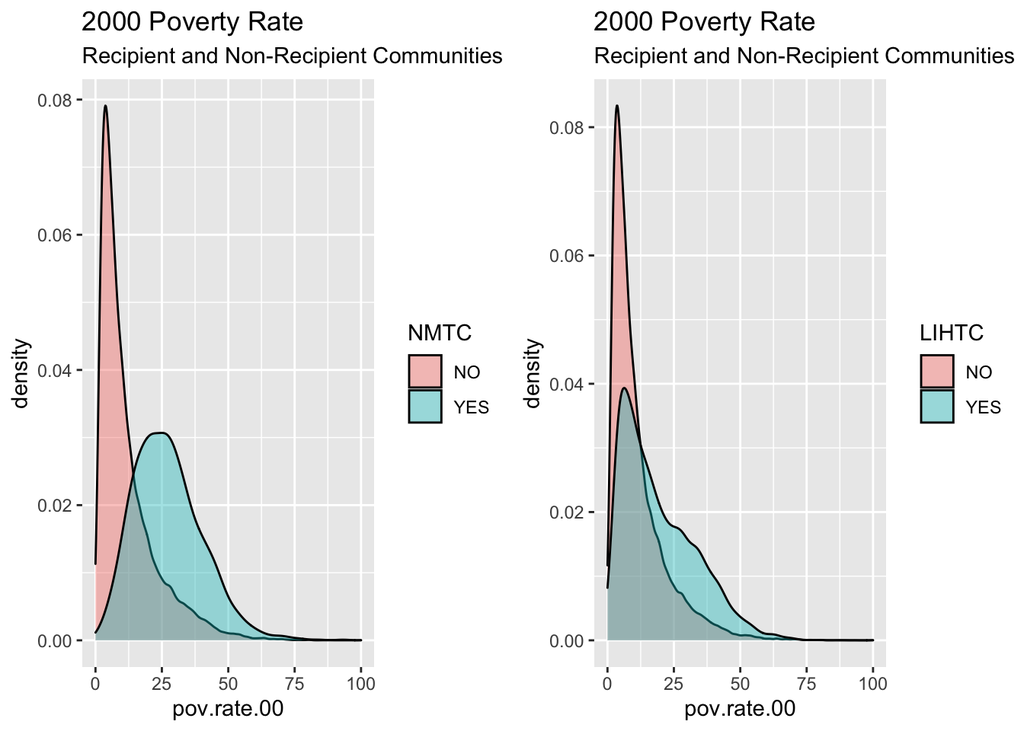

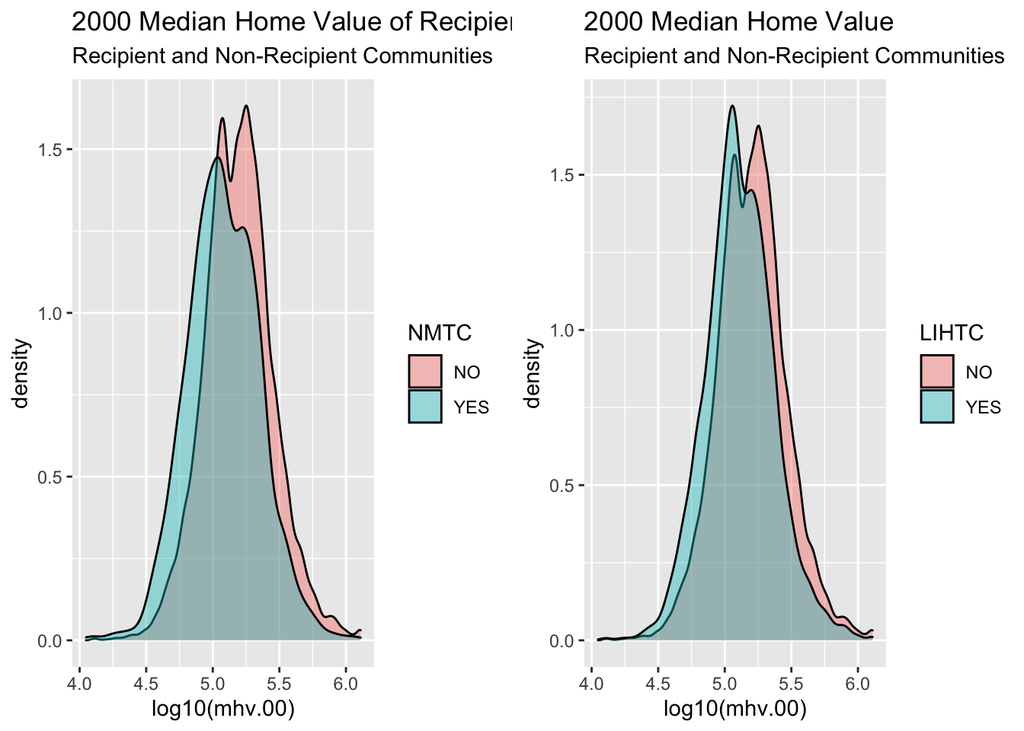

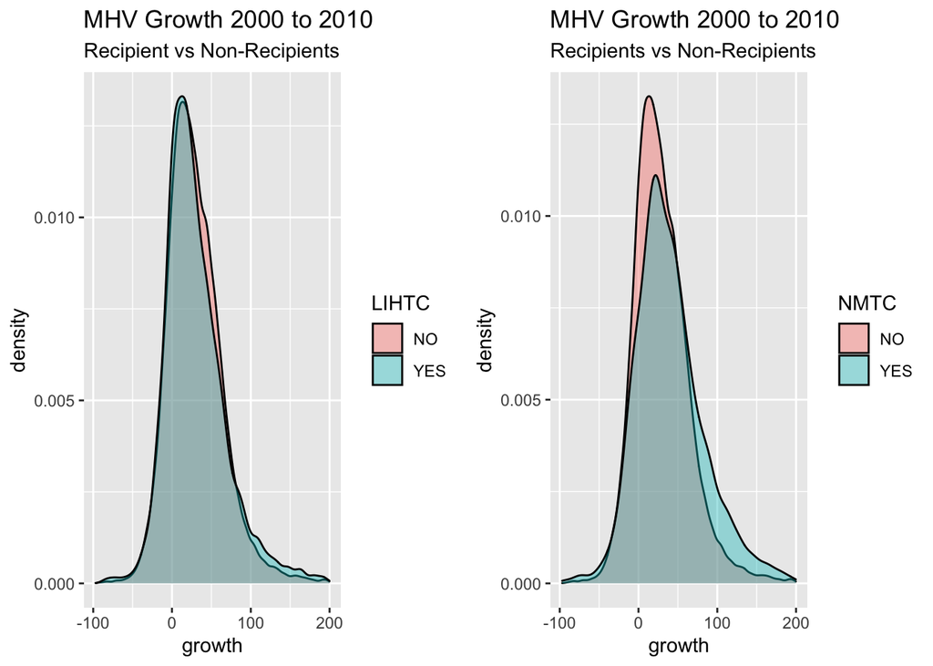

### **Difference-in-Difference Model**

#### The difference-in-difference estimate seems like the most robust option since it allows for pre-treatment differences as long as the parallel lines assumption is met. That is to say, the rates of growth for the treated and untreated tracts were similar in the period 1990 to 2000. Which is another way of saying we believe that C2-C1 is a good approximation of what the home value change would have been without the program.

### NMTC Analysis

|  | Estimate | Std. Error | t value | Pr(>\|t\|) |
| --- | --- | --- | --- | --- |
| **(Intercept)** | 10.48 | 0.009367 | 1119 | 0 |
| **PercentCollegeGrad** | 0.5129 | 0.002166 | 236.8 | 0 |
| **PercentUnemployed** | 0.02875 | 0.002605 | 11.04 | 2.626e-28 |
| **PercentBlackPopulation** | -0.07229 | 0.0009466 | -76.36 | 0 |
| **treat** | 0.07153 | 0.01201 | 5.956 | 2.587e-09 |
| **post** | 0.1545 | 0.003307 | 46.73 | 0 |
| **treat:post** | 0.01779 | 0.01684 | 1.056 | 0.2908 |

Fitting linear model: y ~ PercentCollegeGrad + PercentUnemployed + PercentBlackPopulation + treat + post + treat * post

| Observations | Residual Std. Error | $R^2$ | Adjusted $R^2$ |
| --- | --- | --- | --- |
| 117616 | 0.4783 | 0.4568 | 0.4568 |

| Length | Class | Mode |
| --- | --- | --- |
| 0 | NULL | NULL |

**NMTC Treatment**

|  | *Dependent variable:* |
| --- | --- |
|  | Log Median Home Value |
| Percent College Grads | 0.51*** |
|  | (0.002) |
| Percent Unemployed | 0.03*** |
|  | (0.003) |
| Percent Black Population | -0.07*** |
|  | (0.001) |
| treat | 0.07*** |
|  | (0.01) |
| post | 0.15*** |
|  | (0.003) |
| treat:post | 0.02 |
|  | (0.02) |
| Constant | 10.48*** |
|  | (0.01) |
| Observations | 117,616 |
| R<sup>2</sup> | 0.46 |
| Adjusted R<sup>2</sup> | 0.46 |
| Residual Std. Error | 0.48 (df = 117609) |
| F Statistic | 16,486.30*** (df = 6; 117609) |
| *Note:* | p<0.1; p<0.05; p<0.01 |

### LIHTC Analysis

|  | Estimate | Std. Error | t value | Pr(>\|t\|) |
| --- | --- | --- | --- | --- |
| **(Intercept)** | 10.48 | 0.009396 | 1115 | 0 |
| **PercentCollegeGrad** | 0.5127 | 0.002171 | 236.2 | 0 |
| **PercentUnemployed** | 0.02995 | 0.002603 | 11.51 | 1.264e-30 |
| **PercentBlackPopulation** | -0.07184 | 0.0009499 | -75.63 | 0 |
| **treat** | 0.01631 | 0.005788 | 2.817 | 0.004845 |
| **post** | 0.156 | 0.003468 | 44.96 | 0 |
| **treat:post** | -0.01271 | 0.008082 | -1.572 | 0.1159 |

Fitting linear model: y ~ PercentCollegeGrad + PercentUnemployed + PercentBlackPopulation + treat + post + treat * post

| Observations | Residual Std. Error | $R^2$ | Adjusted $R^2$ |
| --- | --- | --- | --- |
| 117616 | 0.4785 | 0.4565 | 0.4564 |

**LIHTC Treatment**

|  | *Dependent variable:* |
| --- | --- |
|  | Log Median Home Value |
| Percent College Grads | 0.51*** |
|  | (0.002) |
| Percent Unemployed | 0.03*** |
|  | (0.003) |
| Percent Black Population | -0.07*** |
|  | (0.001) |
| treat | 0.02*** |
|  | (0.01) |
| post | 0.16*** |
|  | (0.003) |
| treat:post | -0.01 |
|  | (0.01) |
| Constant | 10.48*** |
|  | (0.01) |
| Observations | 117,616 |
| R<sup>2</sup> | 0.46 |
| Adjusted R<sup>2</sup> | 0.46 |
| Residual Std. Error | 0.48 (df = 117609) |
| F Statistic | 16,461.12*** (df = 6; 117609) |
| *Note:* | p<0.1; p<0.05; p<0.01 |

### Parallel Lines Test

#### NMTC Regression Summary

|  | Estimate | Std. Error | t value | Pr(>\|t\|) |
| --- | --- | --- | --- | --- |
| **(Intercept)** | 11.96 | 0.002666 | 4487 | 0 |
| **treat** | -0.2639 | 0.01584 | -16.66 | 2.977e-62 |
| **post** | 0.2295 | 0.00377 | 60.89 | 0 |
| **treat:post** | 0.09611 | 0.0224 | 4.291 | 1.781e-05 |

Fitting linear model: y ~ treat + post + treat * post

| Observations | Residual Std. Error | $R^2$ | Adjusted $R^2$ |
| --- | --- | --- | --- |
| 118132 | 0.6386 | 0.0351 | 0.03507 |

#### LIHTC Regression Summary

|  | Estimate | Std. Error | t value | Pr(>\|t\|) |
| --- | --- | --- | --- | --- |
| **(Intercept)** | 11.98 | 0.002818 | 4252 | 0 |
| **treat** | -0.2074 | 0.007578 | -27.37 | 2.052e-164 |
| **post** | 0.2315 | 0.003985 | 58.08 | 0 |
| **treat:post** | 0.005895 | 0.01072 | 0.55 | 0.5823 |

Fitting linear model: y ~ treat + post + treat * post

| Observations | Residual Std. Error | $R^2$ | Adjusted $R^2$ |
| --- | --- | --- | --- |
| 118132 | 0.6357 | 0.0437 | 0.04368 |

**NMTC and LITHC Comparison**

|  | *Dependent variable:* |  |
| --- | --- | --- |
|  | Log Median Home Value |  |
|  | NMTC | LIHTC |
|  | (1) | (2) |
| treat | -0.26*** | -0.21*** |
|  | (0.02) | (0.01) |
| post | 0.23*** | 0.23*** |
|  | (0.004) | (0.004) |
| treat:post | 0.10*** | 0.01 |
|  | (0.02) | (0.01) |
| Constant | 11.96*** | 11.98*** |
|  | (0.003) | (0.003) |
| Observations | 118,132 | 118,132 |
| R<sup>2</sup> | 0.04 | 0.04 |
| Adjusted R<sup>2</sup> | 0.04 | 0.04 |
| Residual Std. Error (df = 118128) | 0.64 | 0.64 |
| F Statistic (df = 3; 118128) | 1,432.34*** | 1,799.55*** |
| *Note:* | p<0.1; p<0.05; p<0.01 |  |

### Home value test

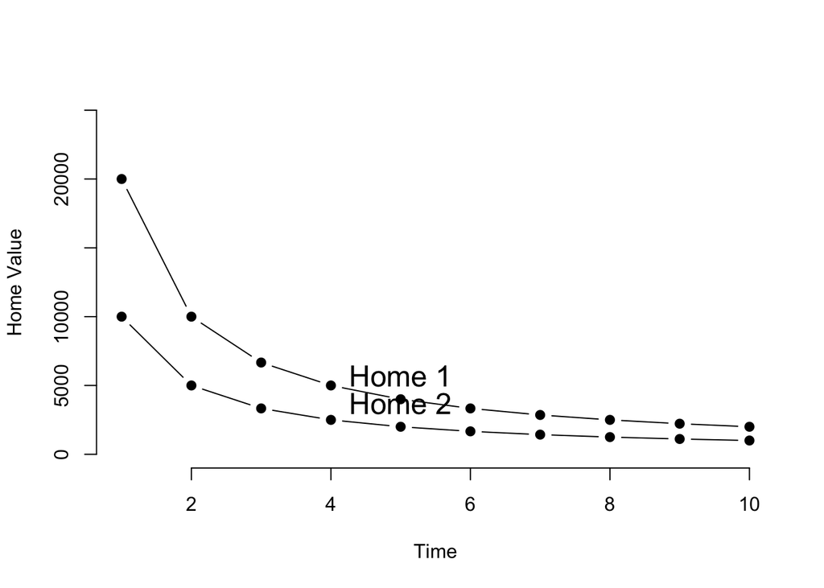

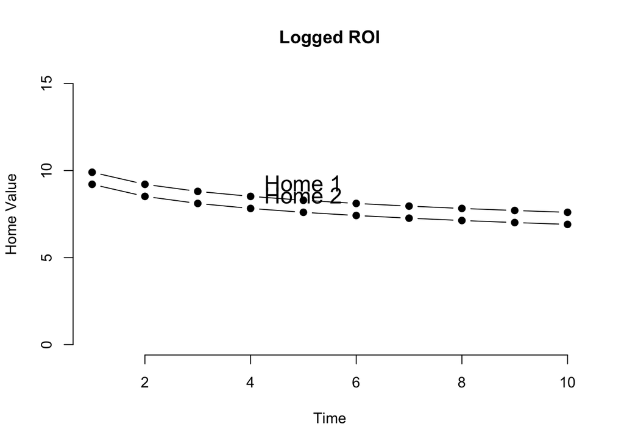

| time | value | log.value |
| --- | --- | --- |
| 1 | 20000 | 9.903 |
| 2 | 10000 | 9.21 |
| 3 | 6667 | 8.805 |
| 4 | 5000 | 8.517 |
| 5 | 4000 | 8.294 |
| 6 | 3333 | 8.112 |
| 7 | 2857 | 7.958 |
| 8 | 2500 | 7.824 |
| 9 | 2222 | 7.706 |
| 10 | 2000 | 7.601 |

### True Growth Rate

```
## [1] -0.5
```

### Growth Rate Approximation

```
## [1] -0.6931472
```

**NMTC- Diff-In-Diff**

|  | *Dependent variable:* |
| --- | --- |
|  | y |
| treat | -0.26*** |
|  | (0.02) |
| post | 0.23*** |
|  | (0.004) |
| treat:post | 0.10*** |
|  | (0.02) |
| Constant | 11.96*** |
|  | (0.003) |
| Observations | 118,132 |
| R<sup>2</sup> | 0.04 |
| Adjusted R<sup>2</sup> | 0.04 |
| Residual Std. Error | 0.64 (df = 118128) |
| F Statistic | 1,432.34*** (df = 3; 118128) |
| *Note:* | p<0.1; p<0.05; p<0.01 |

#### Diff-in-diff model - equation

### C1 = B0

| (Intercept) |
| --- |
| 156581 |

### C2 = B0 + B2

| (Intercept) |
| --- |
| 196984 |

### T1 = B0 + B1

| (Intercept) |
| --- |
| 120265 |

### T2 = B0 + B1 + B2 + B3

| (Intercept) |
| --- |
| 166560 |

### Counterfactual: C2-C1

*40403*

### Our Treatment Group: T2-T1

*46295*

### Treatment difference in difference (T2-T1) - (C2-C1)

*5892*

### Reflection

#### In conclusion, it can be said that NMTC’s model for low-income housing resulted in higher MHV growth than the secular trend, and it may be inferred that this leads to value improvement of neighborhoods, because home prices tend to reflect the quality of life value of the neighborhoods. However, because the NMTC approaach tended to have a ‘middle of the road’ approach to percent poverty tracts chosen, as seen by our data visualizations (“2000 Poverty Rate Comparison of and Non-Recipient Communities”), it is possible that they chose tracts strategically in areas that would have seen growth anyway, and less people in poverty actually benefited from these programs. Testing this hypothesis would require a different framework that was people-based, not place-based.